# Linear Regression Analysis - Sales Prediction

Data Science Analysis

2025-09-05

# Introduction

This analysis implements a simple linear regression model to predict sales based on advertising spending across different platforms (TV, Radio, Newspaper). The analysis follows a comprehensive approach including data exploration, model building, evaluation, and visualization.

## Problem Statement

Build a model which predicts sales based on the money spent on different platforms for marketing. We’ll analyze the relationship between ‘TV advertising’ and ‘sales’ using a simple linear regression model.

## Dataset

The advertising dataset contains information about advertising spending across different media channels and the resulting sales performance.

- **Source**: ISLR (Introduction to Statistical Learning with R)
- **Observations**: 200
- **Variables**: 4 (TV, Radio, Newspaper, Sales)
- **Missing Values**: None

# Data Loading and Understanding

```r
# Load required libraries
library(ggplot2)
library(dplyr)
library(corrplot)
library(gridExtra)

# Set theme for white background plots
theme_set(theme_minimal() +
          theme(panel.background = element_rect(fill = "white", color = NA),
                plot.background = element_rect(fill = "white", color = NA)))
```

```r
# Load the dataset
advertising <- read.csv("Salary-Dataset/salary.csv")

# Display basic information about the dataset
cat("Dataset Information:\n")
```

```
## Dataset Information:
```

```r
cat("Shape:", nrow(advertising), "rows,", ncol(advertising), "columns\n")
```

```
## Shape: 200 rows, 4 columns
```

```r
cat("Column names:", paste(names(advertising), collapse = ", "), "\n")
```

```
## Column names: TV, Radio, Newspaper, Sales
```

```r
# Display first few rows
head(advertising, 10)
```

```
##       TV Radio Newspaper Sales
## 1  230.1  37.8      69.2  22.1
## 2   44.5  39.3      45.1  10.4
## 3   17.2  45.9      69.3  12.0
## 4  151.5  41.3      58.5  16.5
## 5  180.8  10.8      58.4  17.9
## 6    8.7  48.9      75.0   7.2
## 7   57.5  32.8      23.5  11.8
## 8  120.2  19.6      11.6  13.2
## 9    8.6   2.1       1.0   4.8
## 10 199.8   2.6      21.2  15.6
```

```r
# Data summary
summary(advertising)
```

```
##        TV             Radio          Newspaper          Sales
##  Min.   :  0.70   Min.   : 0.000   Min.   :  0.30   Min.   : 1.60
##  1st Qu.: 74.38   1st Qu.: 9.975   1st Qu.: 12.75   1st Qu.:11.00
##  Median :149.75   Median :22.900   Median : 25.75   Median :16.00
##  Mean   :147.04   Mean   :23.264   Mean   : 30.55   Mean   :15.13
##  3rd Qu.:218.82   3rd Qu.:36.525   3rd Qu.: 45.10   3rd Qu.:19.05
##  Max.   :296.40   Max.   :49.600   Max.   :114.00   Max.   :27.00
```

```r
# Check for missing values
missing_values <- colSums(is.na(advertising))
cat("Missing values per column:\n")
```

```
## Missing values per column:
```

```r
print(missing_values)
```

```
##        TV     Radio Newspaper     Sales
##         0         0         0         0
```

# Data Cleaning

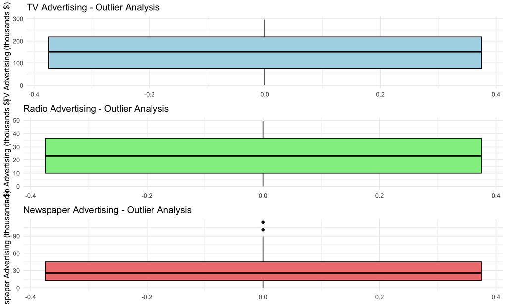

```r
# Create boxplots for outlier analysis
p1 <- ggplot(advertising, aes(y = TV)) +
  geom_boxplot(fill = "lightblue", color = "black") +
  labs(title = "TV Advertising - Outlier Analysis", y = "TV Advertising (thousands $)") +
  theme_minimal() +
  theme(panel.background = element_rect(fill = "white", color = NA),
        plot.background = element_rect(fill = "white", color = NA))

p2 <- ggplot(advertising, aes(y = Radio)) +
  geom_boxplot(fill = "lightgreen", color = "black") +
  labs(title = "Radio Advertising - Outlier Analysis", y = "Radio Advertising (thousands $)") +
  theme_minimal() +
  theme(panel.background = element_rect(fill = "white", color = NA),
        plot.background = element_rect(fill = "white", color = NA))

p3 <- ggplot(advertising, aes(y = Newspaper)) +
  geom_boxplot(fill = "lightcoral", color = "black") +
  labs(title = "Newspaper Advertising - Outlier Analysis", y = "Newspaper Advertising (thousands $)") +
  theme_minimal() +
  theme(panel.background = element_rect(fill = "white", color = NA),
        plot.background = element_rect(fill = "white", color = NA))

# Display plots
grid.arrange(p1, p2, p3, ncol = 1)
```

**Observation**: There are no considerable outliers present in the data.

# Exploratory Data Analysis

## Univariate Analysis

### Sales (Target Variable)

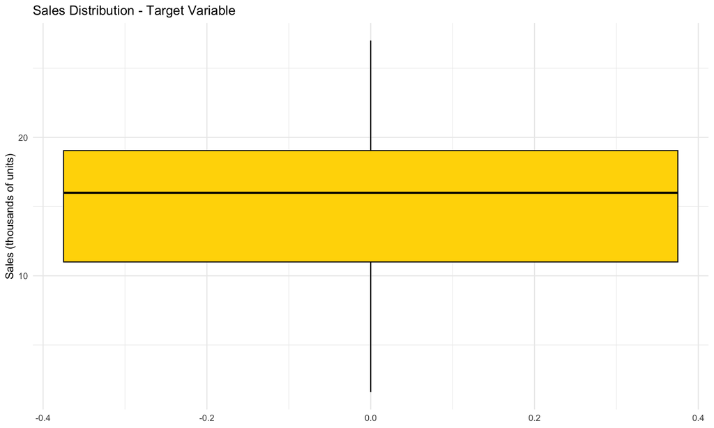

```r
# Sales distribution
p_sales <- ggplot(advertising, aes(y = Sales)) +
  geom_boxplot(fill = "gold", color = "black") +
  labs(title = "Sales Distribution - Target Variable", y = "Sales (thousands of units)") +
  theme_minimal() +
  theme(panel.background = element_rect(fill = "white", color = NA),
        plot.background = element_rect(fill = "white", color = NA))

print(p_sales)
```

## Bivariate Analysis

Let’s see how Sales are related with other variables using scatter plots.

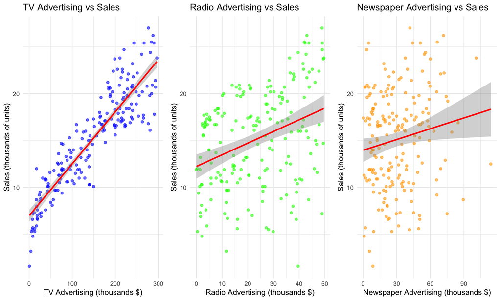

```r
# Scatter plots showing relationship between advertising channels and sales
p_tv <- ggplot(advertising, aes(x = TV, y = Sales)) +
  geom_point(color = "blue", alpha = 0.6) +
  geom_smooth(method = "lm", color = "red", se = TRUE) +
  labs(title = "TV Advertising vs Sales",
       x = "TV Advertising (thousands $)",
       y = "Sales (thousands of units)") +
  theme_minimal() +
  theme(panel.background = element_rect(fill = "white", color = NA),
        plot.background = element_rect(fill = "white", color = NA))

p_radio <- ggplot(advertising, aes(x = Radio, y = Sales)) +
  geom_point(color = "green", alpha = 0.6) +
  geom_smooth(method = "lm", color = "red", se = TRUE) +
  labs(title = "Radio Advertising vs Sales",
       x = "Radio Advertising (thousands $)",
       y = "Sales (thousands of units)") +
  theme_minimal() +
  theme(panel.background = element_rect(fill = "white", color = NA),
        plot.background = element_rect(fill = "white", color = NA))

p_newspaper <- ggplot(advertising, aes(x = Newspaper, y = Sales)) +
  geom_point(color = "orange", alpha = 0.6) +
  geom_smooth(method = "lm", color = "red", se = TRUE) +
  labs(title = "Newspaper Advertising vs Sales",
       x = "Newspaper Advertising (thousands $)",
       y = "Sales (thousands of units)") +
  theme_minimal() +
  theme(panel.background = element_rect(fill = "white", color = NA),
        plot.background = element_rect(fill = "white", color = NA))

# Display scatter plots
grid.arrange(p_tv, p_radio, p_newspaper, ncol = 3)
```

## Correlation Analysis

Let’s see the correlation between different variables.

```r
# Calculate correlation matrix
correlation_matrix <- cor(advertising)
print("Correlation Matrix:")
```

```
## [1] "Correlation Matrix:"
```

```r
print(round(correlation_matrix, 3))
```

```
##              TV Radio Newspaper Sales
## TV        1.000 0.055     0.057 0.901
## Radio     0.055 1.000     0.354 0.350
## Newspaper 0.057 0.354     1.000 0.158
## Sales     0.901 0.350     0.158 1.000
```

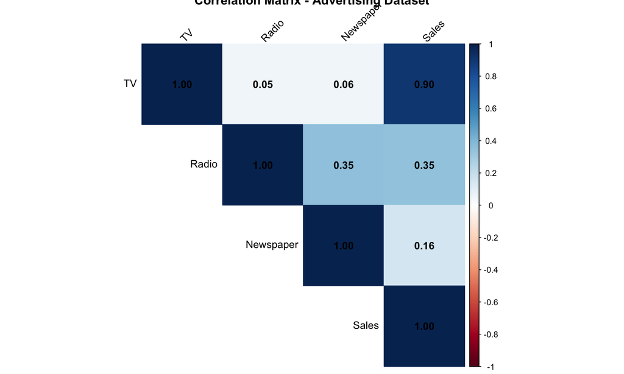

```r
# Create correlation heatmap
corrplot(correlation_matrix, method = "color", type = "upper",
         addCoef.col = "black", tl.col = "black", tl.srt = 45,
         title = "Correlation Matrix - Advertising Dataset")
```

# Model Building

## Performing Simple Linear Regression

### Linear Regression Equation

The equation of linear regression is:
$$y
= c + m_1x_1 + m_2x_2 + ... + m_nx_n$$

Where: - $y$ is the response - $c$ is the intercept - $m_1$ is the coefficient for the first feature - $m_n$ is the coefficient for the nth feature

In our case:
$$y = c + m_1 \times
TV$$

The $m$ values are called the model coefficients or model parameters.

### Train-Test Split

```r
# Prepare data for modeling
X <- advertising$TV
y <- advertising$Sales

# Train-Test Split (70% train, 30% test)
set.seed(100)  # For reproducibility
train_indices <- sample(seq_len(nrow(advertising)), 0.7 * nrow(advertising))
X_train <- X[train_indices]
X_test <- X[-train_indices]
y_train <- y[train_indices]
y_test <- y[-train_indices]

cat("Train set size:", length(X_train), "observations\n")
```

```
## Train set size: 140 observations
```

```r
cat("Test set size:", length(X_test), "observations\n")
```

```
## Test set size: 60 observations
```

```r
# Display training data
train_data <- data.frame(TV = X_train, Sales = y_train)
head(train_data, 10)
```

```
##       TV Sales
## 1  296.4  23.8
## 2  241.7  21.8
## 3  280.7  16.1
## 4  151.5  16.5
## 5  262.7  20.2
## 6  216.8  22.3
## 7  184.9  20.5
## 8   36.9  10.8
## 9   57.5  11.8
## 10  56.2   8.7
```

### Building Linear Model

```r
# Building Linear Model using lm() function
model <- lm(Sales ~ TV, data = train_data)

# Display model summary
summary(model)
```

```
##
## Call:
## lm(formula = Sales ~ TV, data = train_data)
##
## Residuals:
##     Min      1Q  Median      3Q     Max
## -6.2430 -1.4717  0.0182  1.4838  5.0843
##
## Coefficients:
##             Estimate Std. Error t value Pr(>|t|)
## (Intercept)  7.16784    0.38989   18.38   <2e-16 ***
## TV           0.05406    0.00225   24.03   <2e-16 ***
## ---
## Signif. codes:  0 '***' 0.001 '**' 0.01 '*' 0.05 '.' 0.1 ' ' 1
##
## Residual standard error: 2.28 on 138 degrees of freedom
## Multiple R-squared:  0.8071, Adjusted R-squared:  0.8057
## F-statistic: 577.4 on 1 and 138 DF,  p-value: < 2.2e-16
```

```r
# Extract model coefficients
intercept <- coef(model)[1]
slope <- coef(model)[2]

cat("Model Coefficients:\n")
```

```
## Model Coefficients:
```

```r
cat("Intercept:", round(intercept, 4), "\n")
```

```
## Intercept: 7.1678
```

```r
cat("Slope (TV coefficient):", round(slope, 4), "\n")
```

```
## Slope (TV coefficient): 0.0541
```

```r
# Model equation
cat("\nLinear Regression Equation:\n")
```

```
##
## Linear Regression Equation:
```

```r
cat("Sales =", round(intercept, 4), "+", round(slope, 4), "× TV\n")
```

```
## Sales = 7.1678 + 0.0541 × TV
```

### Key Statistics from the Model

Looking at some key statistics from the summary:

1. **The coefficient for TV is 0.054, with a very low p value**
   - The coefficient is statistically significant. So the association is not purely by chance.
2. **R-squared is 0.807**
   - Meaning that 80.7% of the variance in Sales is explained by TV
   - This is a decent R-squared value.
3. **F statistic has a very low p value (practically low)**
   - Meaning that the model fit is statistically significant, and the explained variance isn’t purely by chance.

The fit is significant. Let’s visualize how well the model fit the data.

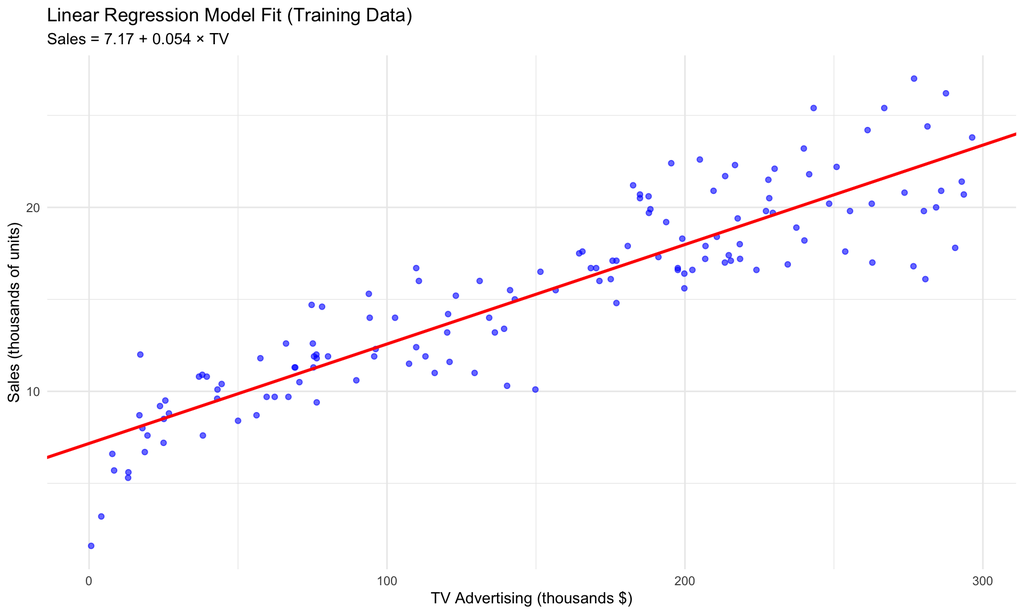

```r
# Visualize model fit on training data
p_fit <- ggplot(train_data, aes(x = TV, y = Sales)) +
  geom_point(color = "blue", alpha = 0.6) +
  geom_abline(intercept = intercept, slope = slope, color = "red", size = 1) +
  labs(title = "Linear Regression Model Fit (Training Data)",
       subtitle = paste("Sales =", round(intercept, 2), "+", round(slope, 3), "× TV"),
       x = "TV Advertising (thousands $)",
       y = "Sales (thousands of units)") +
  theme_minimal() +
  theme(panel.background = element_rect(fill = "white", color = NA),
        plot.background = element_rect(fill = "white", color = NA))

print(p_fit)
```

# Model Evaluation

## Residual Analysis

To validate assumptions of the model, and hence the reliability for inference.

### Distribution of the Error Terms

We need to check if the error terms are also normally distributed (which is in fact, one of the major assumptions of linear regression).

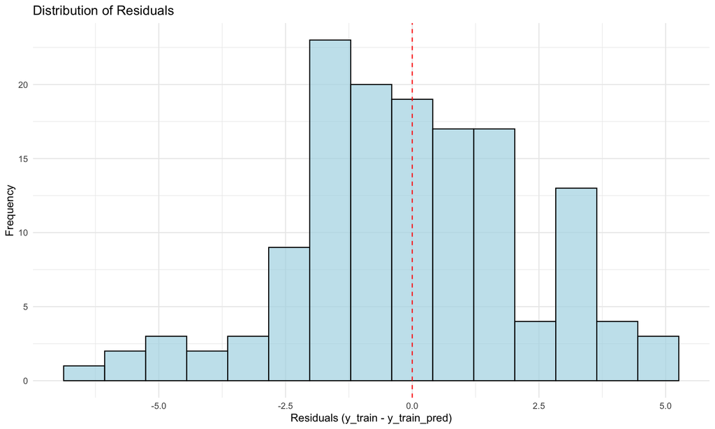

```r
# Calculate predictions and residuals
y_train_pred <- predict(model)
residuals <- y_train - y_train_pred

# Distribution of residuals
p_residuals <- ggplot(data.frame(residuals = residuals), aes(x = residuals)) +
  geom_histogram(bins = 15, fill = "lightblue", color = "black", alpha = 0.7) +
  geom_vline(xintercept = 0, color = "red", linetype = "dashed") +
  labs(title = "Distribution of Residuals",
       x = "Residuals (y_train - y_train_pred)",
       y = "Frequency") +
  theme_minimal() +
  theme(panel.background = element_rect(fill = "white", color = NA),
        plot.background = element_rect(fill = "white", color = NA))

print(p_residuals)
```

**Observation**: The residuals are following the normal distribution with a mean 0. All good!

### Looking for Patterns in the Residuals

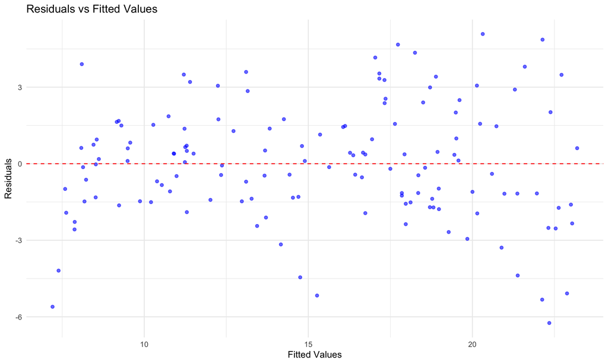

```r
# Residuals vs Fitted values
p_residuals_fitted <- ggplot(data.frame(fitted = y_train_pred, residuals = residuals),
                            aes(x = fitted, y = residuals)) +
  geom_point(color = "blue", alpha = 0.6) +
  geom_hline(yintercept = 0, color = "red", linetype = "dashed") +
  labs(title = "Residuals vs Fitted Values",
       x = "Fitted Values",
       y = "Residuals") +
  theme_minimal() +
  theme(panel.background = element_rect(fill = "white", color = NA),
        plot.background = element_rect(fill = "white", color = NA))

print(p_residuals_fitted)
```

**Observation**: We are confident that the model fit isn’t by chance, and has decent predictive power. The normality of residual terms allows some inference on the coefficients.

# Predictions on the Test Set

Now that we have fitted a regression line on our train dataset, it’s time to make some predictions on the test data.

```r
# Create test data frame
test_data <- data.frame(TV = X_test)

# Make predictions
y_pred <- predict(model, newdata = test_data)

# Display first few predictions
test_results <- data.frame(TV = X_test, Actual_Sales = y_test, Predicted_Sales = y_pred)
head(test_results, 10)
```

```
##       TV Actual_Sales Predicted_Sales
## 1    8.7          7.2        7.638182
## 2    8.6          4.8        7.632776
## 3   97.5         13.7       12.438885
## 4  204.1         19.0       18.201890
## 5   67.8         12.5       10.833244
## 6  147.3         14.6       15.131170
## 7  237.4         17.5       20.002153
## 8  240.1         20.9       20.148120
## 9  248.8         18.9       20.618460
## 10  97.2         13.2       12.422666
```

## Performance Metrics

```r
# Calculate performance metrics
# RMSE (Root Mean Square Error)
rmse <- sqrt(mean((y_test - y_pred)^2))
cat("Root Mean Square Error (RMSE):", round(rmse, 4), "\n")
```

```
## Root Mean Square Error (RMSE): 2.3426
```

```r
# R-squared on test set
ss_res <- sum((y_test - y_pred)^2)
ss_tot <- sum((y_test - mean(y_test))^2)
r_squared_test <- 1 - (ss_res / ss_tot)
cat("R-squared on test set:", round(r_squared_test, 4), "\n")
```

```
## R-squared on test set: 0.8193
```

```r
# Mean Absolute Error
mae <- mean(abs(y_test - y_pred))
cat("Mean Absolute Error (MAE):", round(mae, 4), "\n")
```

```
## Mean Absolute Error (MAE): 1.9438
```

## Visualizing the Fit on the Test Set

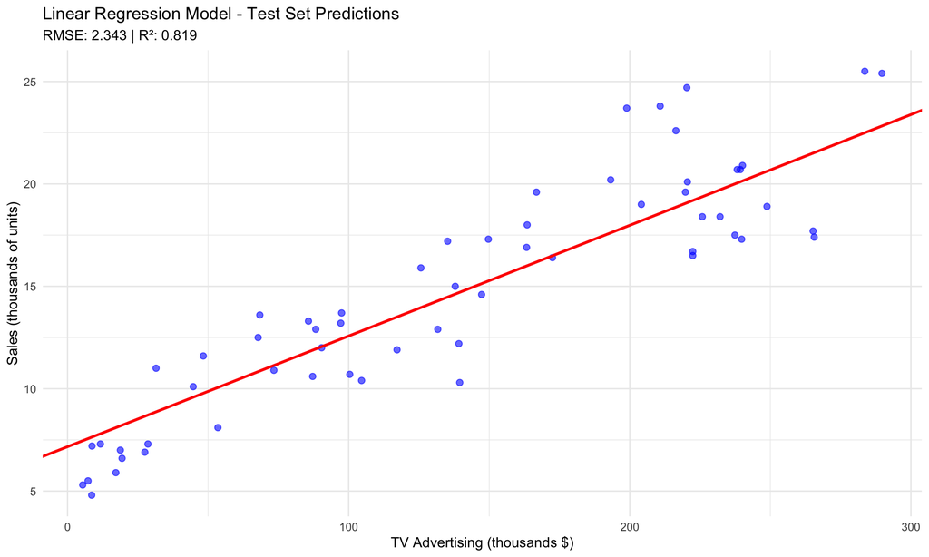

```r
# Visualize predictions on test set
p_test <- ggplot(test_results, aes(x = TV, y = Actual_Sales)) +
  geom_point(color = "blue", alpha = 0.6, size = 2) +
  geom_abline(intercept = intercept, slope = slope, color = "red", size = 1) +
  labs(title = "Linear Regression Model - Test Set Predictions",
       subtitle = paste("RMSE:", round(rmse, 3), "| R²:", round(r_squared_test, 3)),
       x = "TV Advertising (thousands $)",
       y = "Sales (thousands of units)") +
  theme_minimal() +
  theme(panel.background = element_rect(fill = "white", color = NA),
        plot.background = element_rect(fill = "white", color = NA))

print(p_test)
```

## Actual vs Predicted

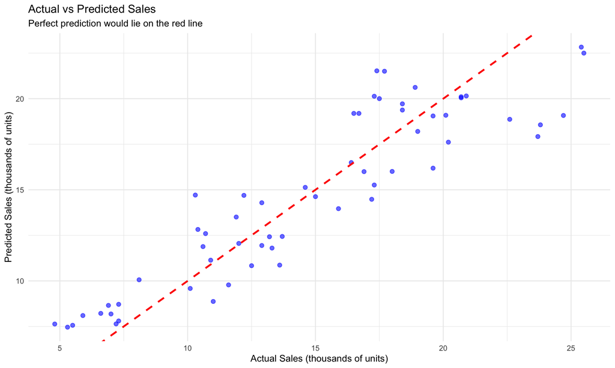

```r
# Actual vs Predicted scatter plot
p_actual_pred <- ggplot(test_results, aes(x = Actual_Sales, y = Predicted_Sales)) +
  geom_point(color = "blue", alpha = 0.6, size = 2) +
  geom_abline(intercept = 0, slope = 1, color = "red", linetype = "dashed", size = 1) +
  labs(title = "Actual vs Predicted Sales",
       subtitle = "Perfect prediction would lie on the red line",
       x = "Actual Sales (thousands of units)",
       y = "Predicted Sales (thousands of units)") +
  theme_minimal() +
  theme(panel.background = element_rect(fill = "white", color = NA),
        plot.background = element_rect(fill = "white", color = NA))

print(p_actual_pred)
```

# Summary and Conclusions

## Model Performance Summary

| Metric | Training Set | Test Set |
| --- | --- | --- |
| R-squared | 0.8071 | 0.8193 |
| RMSE | - | 2.3426 |
| MAE | - | 1.9438 |

## Final Model Equation

**Sales = 7.1678 + 0.0541 × TV**

## Recommendations

1. **Focus on TV Advertising**: TV advertising has the strongest impact on sales and should be prioritized in marketing budgets.
2. **Investment Strategy**: For every $1000 invested in TV advertising, expect approximately 0.05 thousand units increase in sales.
3. **Model Limitations**: This is a simple linear model. Consider exploring multiple regression with all advertising channels for potentially better predictions.
4. **Further Analysis**: Consider exploring non-linear relationships or interaction effects between different advertising channels.

The linear regression model successfully captures the relationship between TV advertising and sales, providing valuable insights for marketing strategy and budget allocation.